# gilmore-nysds-2016

2016-08-16

## Curating identifiable data with Databrary

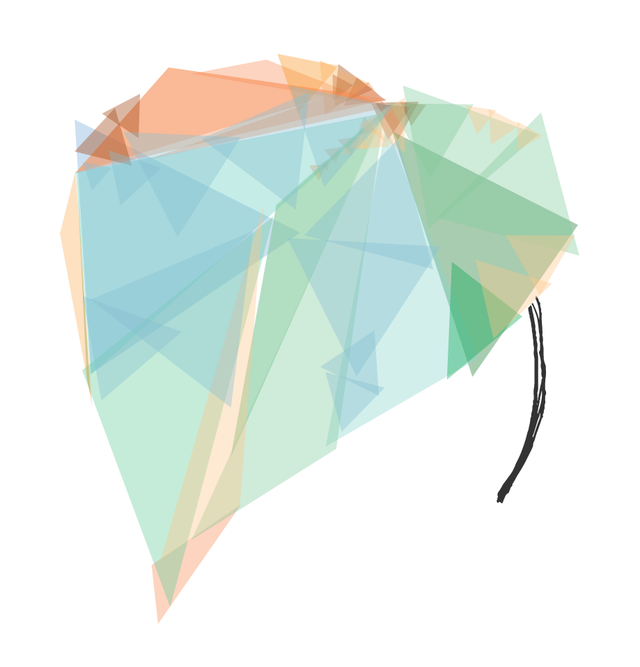

## Acknowledgments

- [NSF BCS-1238599](http://www.nsf.gov/awardsearch/showAward?AWD_ID=1238599&HistoricalAwards=false)
- [NICHD U01-HD-076595](https://projectreporter.nih.gov/project_info_description.cfm?aid=8531595&icde=15908155&ddparam=&ddvalue=&ddsub=&cr=1&csb=default&cs=ASC)
- [Society for Research in Child Development (SRCD)](http://srcd.org)
- NYU Libraries, NYU IT, IRB, and OSP

## TL; DR

- Psychology is harder than physics
- Video uniquely informative about behavior
- Video is essential for reproducible science of behavior
  - Even where video is *not* the primary raw data
- [Databrary](http://databrary.org) specializes in storing and sharing research video + metadata

## TL; DR

- Video is identifiable, but it *can* be securely stored, managed, and shared
- **All** behavioral scientists should collect and share videos of their research methods.
- Video (+ other streams) can serve as the core of a multivariate/multi-level big data science of behavior

## Why psychology is harder than physics

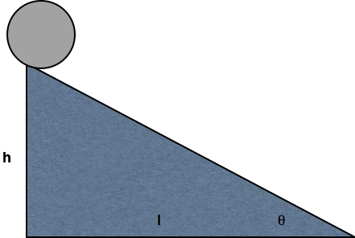

## Why psychology is harder than physics

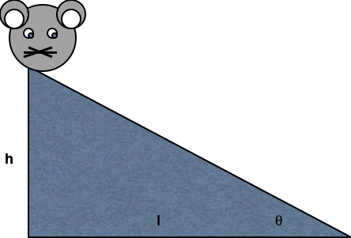

## Video is a uniquely informative source of evidence about behavior

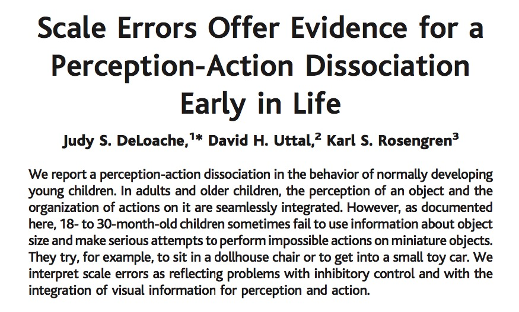

[(J. S. DeLoache, Uttal, and Rosengren 2004)](http://doi.org/10.1126/science.1093567)

[video not shown]

[(J. DeLoache 2014)](http://doi.org/10.17910/B7H019)

[video not shown]

[(Yu 2016)](http://doi.org/10.17910/B7.236)

[interactive chart not shown]

[(Batra et al. 2016)](http://doi.org/10.1542/peds.2016-1533)

[video not shown]

[(Wilkinson 2014)](http://doi.org/10.17910/B7G59R)

[video not shown]

[(Wilkinson 2014)](http://doi.org/10.17910/B7G59R)

[video not shown]

[(Wilkinson 2014)](http://doi.org/10.17910/B7G59R)

## Is behavioral science reproducible?

- Nosek et al. [(Collaboration 2015)](http://doi.org/10.1126/science.aac4716)
- vs. Gilbert et al. [(Gilbert et al. 2016)](http://doi.org/10.1126/science.aad7243)

[figure not shown]

[figure not shown]

## Why the dispute; what to do?

- Behavior rich, complex
- Numeric, text-based measures reduce that complexity
- **Video captures and preserves it**

[video not shown]

[video not shown]

[interactive chart not shown]

## Why the dispute; what to do?

- Replications can fail due to methodological differences
- Methods sections can't possibly report all essential details
- **Video captures and preserves it**

[video not shown]

## A reproducible behavioral science *must*…

- Video record all tasks, measures, and behaviors
- Share the recordings openly with other researchers

## *Journal of Visualized Experiments*

[interactive chart not shown]

## A reproducible behavioral science must *also*…

- Share all questionnaires, tasks, displays
- Share statistical, computational, data workflows
- Make it easy to share from the beginning
- Seek permission to share data from participants
- Store data securely

[interactive chart not shown]

## [Databrary.org](http://databrary.org)

- Digital data library specialized for research video
- Video/audio + participant/context metadata
- Share displays, materials, text-based data files
- Policy framework for sharing identifiable data
- Developmental focus, but not exclusive

## [Databrary.org](http://databrary.org) facilitates data sharing, re-use, preservation

- High capacity, centralized storage
- Transcoding to common, interoperable formats
- Long-term preservation

## Databrary helps to overcomes barriers to sharing video

- Policies for sharing identifiable video data
- Tools for reproducibly coding video
- Tools for "active curation" == during data collection
- Tools for searching, filtering

## Policies

- Restrict access to authorized researchers (& affiliates)
  - PIs and the trainees they supervise
  - Institutional [access agreement](https://databrary.org/access/policies/agreement.html)
- Seek permission to share data from participants
  - Release [template](https://databrary.org/access/policies/release-template.html); [script](https://databrary.org/access/guide/investigators/release/asking/script.html); sample [video](https://databrary.org/video/example-video-1.mp4)

## Standardized (reproducible) release levels

[figure not shown]

## Tools for coding video

- Raw research video must be coded by human observers
- [Datavyu](http://datavyu.org) a free, [open source](https://github.com/databrary/datavyu) coding tool
- Add codes, annotations time-locked to video segments
- Turn behavior into quantifiable data
- Ruby API for [scripting](https://github.com/databrary/Datavyu-Example-Scripts) reproducible workflows

[figure not shown]

[video not shown]

## Tools for curating data **as it is collected**

- After-the-fact curation burdensome
- Databrary organizes, shares, standardized participant metadata
- Sharing based on
  - user access level
  - participant permission

## Databrary's structure

- Datasets have own page; shared datasets have DOIs.
- Data about testing *sessions* (locations, dates/times, people) stored in *spreadsheet*
- Session data organized in *timeline*
- Store data AND materials (displays, protocols, etc.)

## [(Adolph 2013)](http://dx.doi.org/10.17910/B7MW2K)

[interactive chart not shown]

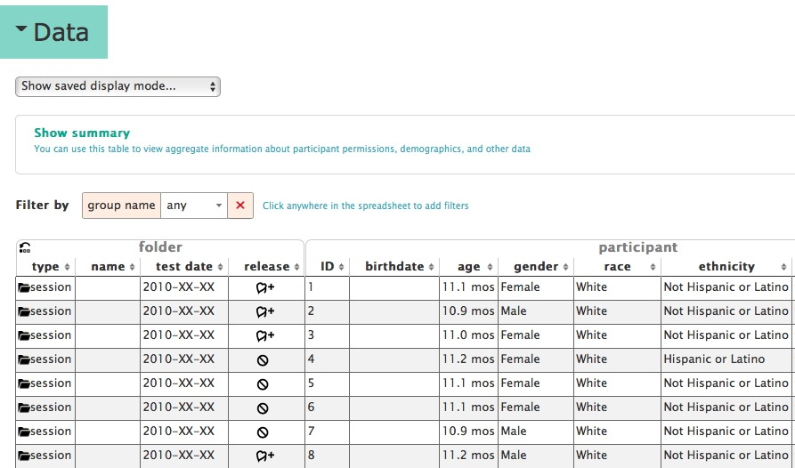

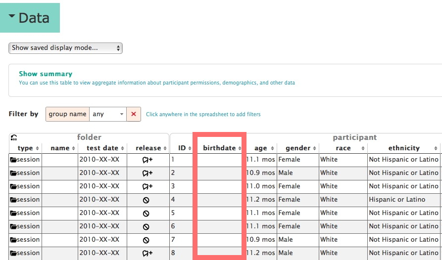

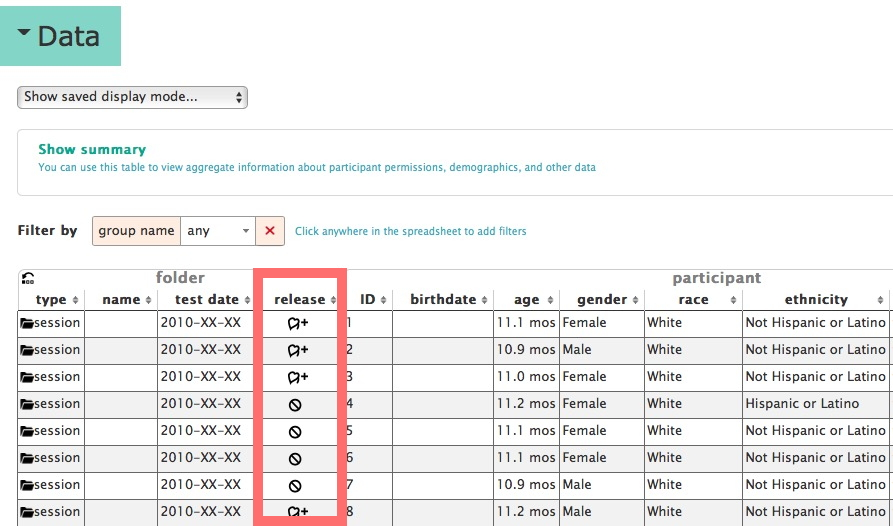

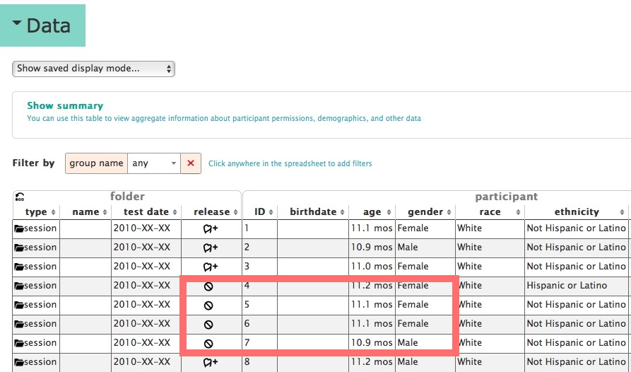

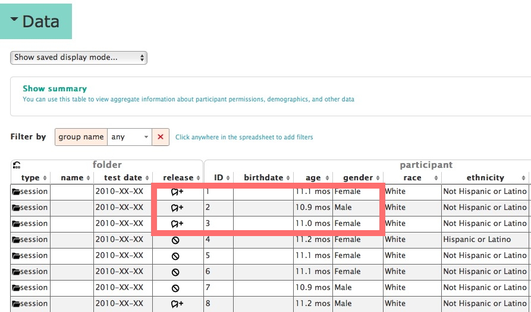

[figure not shown]

[(Adolph 2013)](http://dx.doi.org/10.17910/B7MW2K)

[interactive chart not shown]

[(Jayaraman 2014)](http://doi.org/10.17910/B7988V)

## Tools for searching, filtering by participant characteristics

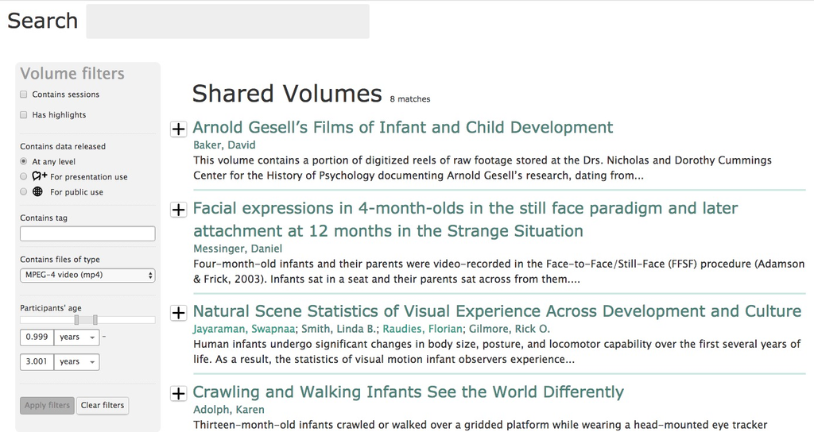

## "Big" questions about behavior require big(ger) data

[figure not shown]

## "Big" questions about behavior require big(ger) data

- Multiple levels of spatial, temporal resolution
- Linked data sets and streams
- Key linkage variables: *when* (time), *where* (location), *who* (age, gender)
- Video is a spatially and temporally rich time series

## How data scientists can help…

- Semi-automated video annotation
- Speech stream extraction from natural video, transcription, ms-level precision
- Multivariate time series visualization, data reduction, analysis
- Linking data, while preserving privacy

## Take homes

- Video uniquely captures complexity & richness of behavior
- Video captures vital methodological details
- Identifiable video (and other data) can be shared securely and ethically
- Preparing to share reduces the burden

## Take homes

- Video data sharing essential for a reproducible, robust behavioral science
- Video can serve as the core of a big data revolution in behavioral science

[interactive chart not shown]

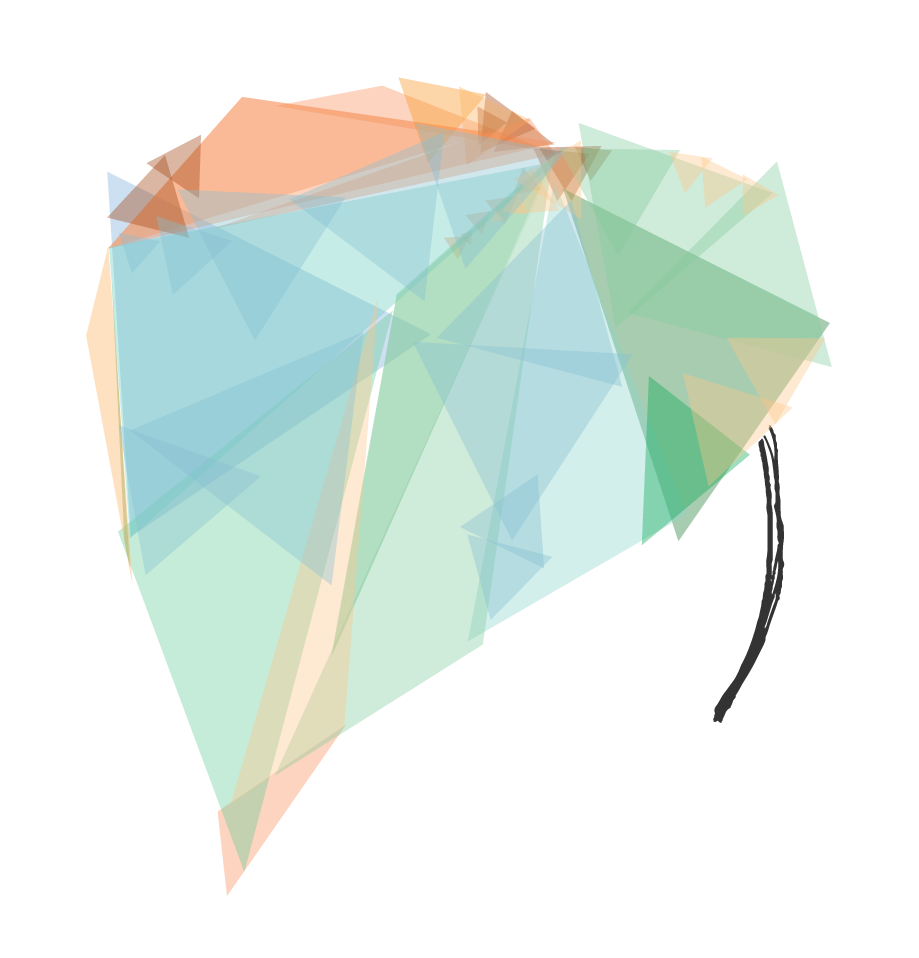

[interactive chart not shown]

## References

Adolph, Karen; 2013. “Infants Crawling and Walking over High and Low Bridges.” Databrary. doi:10.17910/B7MW2K.

Batra, Erich K., Douglas M. Teti, Eric W. Schaefer, Brooke A. Neumann, Elizabeth A. Meek, and Ian M. Paul. 2016. “Nocturnal Video Assessment of Infant Sleep Environments.” *Pediatrics*, August, e20161533. doi:10.1542/peds.2016-1533.

DeLoache, Judy. 2014. “Scale Errors Offer Evidence for a Perception-Action Dissociation Early in Life.” Databrary. doi:10.17910/B7H019.

DeLoache, Judy S., David H. Uttal, and Karl S. Rosengren. 2004. “Scale Errors Offer Evidence for a Perception-Action Dissociation Early in Life.” *Science* 304 (5673): 1027–9. doi:10.1126/science.1093567.

Frank, Michael C.; 2014. “Representing Exact Number Visually Using Mental Abacus.” Databrary. doi:10.17910/B7PP4W.

Gilbert, Daniel T., Gary King, Stephen Pettigrew, and Timothy D. Wilson. 2016. “Comment on ‘Estimating the Reproducibility of Psychological Science’.” *Science* 351 (6277): 1037–7. doi:10.1126/science.aad7243.

Wilkinson, Krista; 2014. “Preliminary Investigation of Visual Attention to Human Figures in Photographs: Potential Considerations for the Design of Aided AAC Visual Scene Displays.” Databrary. doi:10.17910/B7G59R.

Yu, Chen; 2016. “The Social Origins of Sustained Attention in One-Year-Old Human Infants.” Databrary. doi:10.17910/B7.236.